# INFSCI 2595 Final Project

Part 2D1, Regression - Resampling - LM

Zhenyu Li

2022-04-18

```r
library(tidyverse)
theme_set(theme_linedraw())
library(tidymodels)
tidymodels_prefer()
source("./scripts/utils.R")
```

```r
df <- readr::read_csv("./data/final_project_train.csv", col_names = TRUE)
df_regr <- df %>% select(-c(rowid,outcome)) %>% mutate(response = log(response))
```

## Linear Models

Train the 2 predefined linear models and 3 custom basis linear models selected from section 2A using resampling.

**Create the blueprints for data preprocessing & feature engineering.**

**The preprocessing steps.**

```r
bp_prep <- recipe(response ~ ., data=df_regr) %>%
  step_normalize(all_numeric_predictors())
  # prep(training=df_regr, retain=T) %>% bake(new_data=NULL)
```

### Predefined models

**`2D1`: All categorical and continuous inputs - linear additive features.**

```r
bp_2D1 <- bp_prep %>%
  step_dummy(all_nominal_predictors())
```

**`2D2`: All pairwise interactions of continuous inputs, include additive categorical features.**

```r
bp_2D2 <- bp_prep %>%
  step_interact(~ all_numeric_predictors():all_numeric_predictors(), sep = ":") %>%
  step_dummy(all_nominal_predictors())
```

### Custom models

Import the earlier models that are referenced. Pool the inputs that need to create nonlinear features on.

```r
mod_2Ac1 <- readr::read_rds("./models/mod_2Ac1")
mod_2Ac3 <- readr::read_rds("./models/mod_2Ac3")
mod_2Ac4 <- readr::read_rds("./models/mod_2Ac4")

nonlin_pred <- c("xa_03","xa_05","xa_08",
                 "xb_03","xb_05","xb_08",
                 "xn_03","xn_05","xn_08",
                 "xs_01","xs_04","xs_06",
                 "xw_01","xw_02","xw_03")
```

**`2D3_2Ac1`: Linear additive of the nonlinear features and the rest.**

```r
bp_2D3_2Ac1 <- bp_prep %>%
  step_ns(all_of(nonlin_pred), deg_free = 2) %>%
  step_dummy(all_nominal_predictors())

# check # of features with corresponding model (+response -intercept)
bp_2D3_2Ac1 %>% prep(training=df_regr, retain=T) %>% bake(new_data=NULL) %>% ncol()
```

```
## [1] 59
```

```r
coef(mod_2Ac1) %>% length()
```

```
## [1] 59
```

**`2D4_2Ac3`: Interact `region` with only the nonlinear features, additive for the rest.**

```r
bp_2D4_2Ac3 <- bp_prep %>%
  step_ns(all_of(nonlin_pred), deg_free = 2) %>%
  step_dummy(region, one_hot = T) %>%
  step_dummy(customer, one_hot = F) %>%
  step_interact(~ starts_with("region"):contains("_ns_"), sep = ":") %>%
  # remove the additive nonlinear features and the regions
  step_rm(starts_with("x") & contains("_ns_")) %>%
  step_rm(ends_with("XX"), ends_with("YY"), ends_with("ZZ"))

# check # of features with corresponding model (+response -intercept)
bp_2D4_2Ac3 %>% prep(training=df_regr, retain=T) %>% bake(new_data=NULL) %>% ncol()
```

```
## [1] 117
```

```r
coef(mod_2Ac3) %>% length()
```

```
## [1] 117
```

**`2D5_2Ac4`: All pairwise interactions for all input variables.**

```r
bp_2D5_2Ac4 <- bp_prep %>%
  step_interact(~ all_numeric_predictors():all_numeric_predictors(), sep=":") %>%
  step_dummy(all_nominal_predictors()) %>%
  step_interact(~ starts_with("region"):matches("^x.{1}_\\d+$"), sep=":") %>%
  step_interact(~ starts_with("customer"):matches("^x.{1}_\\d+$"), sep=":") %>%
  step_interact(~ matches("^region_.{2}$"):matches("^customer_.{1,6}$"), sep=":")

# check # of features with corresponding model (+response -intercept)
bp_2D5_2Ac4 %>% prep(training=df_regr, retain=T) %>% bake(new_data=NULL) %>% ncol()
```

```
## [1] 918
```

```r
coef(mod_2Ac4) %>% length()
```

```
## [1] 918
```

## Resampling

### Setup

**Define the resampling scheme.**

- Use 5 fold cross-validation with 5 repeats for resampling.
- Will compare RMSE, MAE and R-Squared metrics.
- Model specification: use `lm` engine to fit the models.

```r
set.seed(1324)
cv_folds <- vfold_cv(df_regr, v = 5, repeats = 5)
my_metrics <- metric_set(rmse, mae, rsq)
lm_spec <- linear_reg() %>% set_engine("lm")
```

**Create workflow set to fit.**

```r
lm_wset <- workflow_set(
  preproc = list(
    all_additive = bp_2D1,
    all_cont_pairwise = bp_2D2,
    nonlin_additive = bp_2D3_2Ac1,
    region_interact = bp_2D4_2Ac3,
    all_pairwise = bp_2D5_2Ac4
    ),
  models = list(lm = lm_spec)
  )
```

### Execute

Note: to speed up knit, these two code blocks are set `eval=FALSE`. They can be manually executed in the rmarkdown file.

```r
tune_2D_lm <- lm_wset %>%
  workflow_map(
    fn = "fit_resamples",
    resamples = cv_folds,
    metrics = my_metrics,
    control = control_resamples(save_pred = F),
    verbose = T
  )
```

```r
readr::write_rds(tune_2D_lm,"./models/tune_2D_lm")
```

## Conclusions

```r
tune_2D_lm <- readr::read_rds("./models/tune_2D_lm")
```

### Performance

**Visualize and compare performances across 5 linear models.**

Due to the extreme values of the two pairwise interaction models, the y-axis scale is set to square root scale.

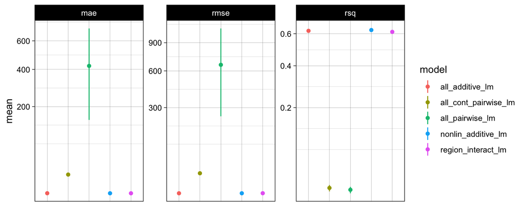

```r
tune_2D_lm %>% collect_metrics() %>%
  ggplot(aes(x=wflow_id, color=wflow_id)) +
  geom_linerange(aes(ymin=mean-std_err, ymax=mean+std_err))+
  geom_point(aes(y=mean), position = position_dodge(0.8)) +
  facet_wrap(~ .metric, scales = "free_y") +
  scale_y_sqrt() +
  theme(axis.title.x=element_blank(), axis.text.x=element_blank(), axis.ticks.x=element_blank()) +
  labs(color="model")
```

Remove both models with pairwise interactions from visualization, since they have poor performances (`mod_2D2`, `mod2D5`).

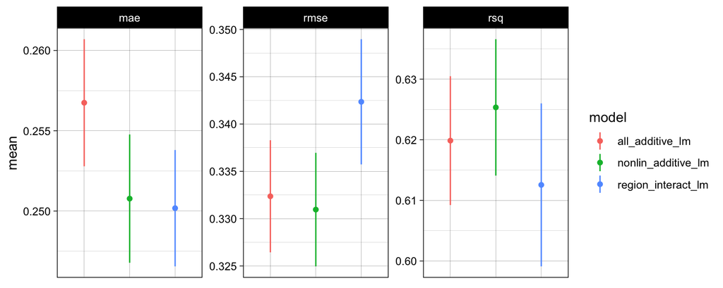

```r
tune_2D_lm %>% collect_metrics() %>%
  filter(!grepl("_pairwise_", wflow_id)) %>%
  ggplot(aes(x=wflow_id, color=wflow_id)) +
  geom_linerange(aes(ymin=mean-std_err,ymax=mean+std_err)) +
  geom_point(aes(y=mean), position = position_dodge(0.8)) +
  facet_wrap(~ .metric, scales = "free_y") +
  theme(axis.title.x=element_blank(), axis.text.x=element_blank(), axis.ticks.x=element_blank()) +
  labs(color="model")
```

### Best Model

**Retrain the best model with resampling, and save predictions.**

```r
lm_best_wflow_mae <- "nonlin_additive_lm"

mod_2D_lm_best_wflow <- lm_wset %>%
  extract_workflow(lm_best_wflow_mae)

mod_2D_lm_best_resample <-
  mod_2D_lm_best_wflow %>%
  fit_resamples(
    cv_folds,
    metrics = my_metrics,
    control = control_resamples(save_pred = T)
  )

mod_2D_lm_best_resample %>% collect_metrics() %>% select(-.config, -.estimator)
```

```
## # A tibble: 3 × 4
##   .metric  mean     n std_err
##   <chr>   <dbl> <int>   <dbl>
## 1 mae     0.251    25 0.00400
## 2 rmse    0.331    25 0.00600
## 3 rsq     0.625    25 0.0112
```

```r
save_models(mget(ls(pattern = "^mod_2D_lm")))
```